# ALAMforFI

## Time Series Analysis

Let’s simulate a further 120 minutes (2 hours) of our market data to run our model on. To create an accurate forecast we first need to uncover some properties of our data using Time Series Analysis. Specifically, ACF and PACF plots.

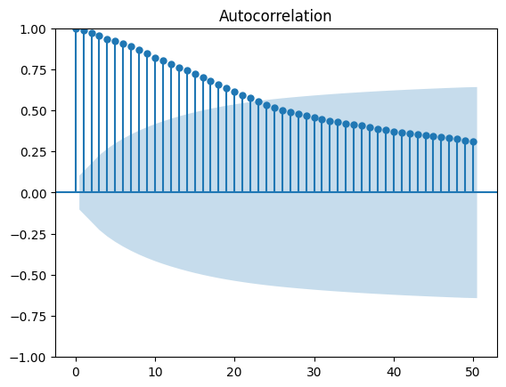

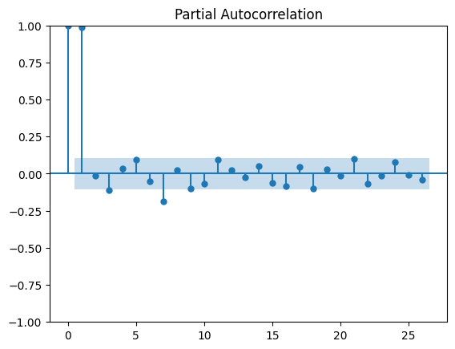

```python
horizon = 60*2
history = 60*6
TS_lastsixhour = (get_raw_forex_data(def_pair,def_freq)["Close"])[-history:]
TS_lastsixhour.index = pd.to_datetime(TS_lastsixhour.index)
n = horizon + len(TS_lastsixhour)
last_value = TS_lastsixhour.iloc[-1]  # Get the last yhat value

plot_acf(TS_lastsixhour,lags=50);
plot_pacf(TS_lastsixhour);
```

Let’s fit our ARIMA model.

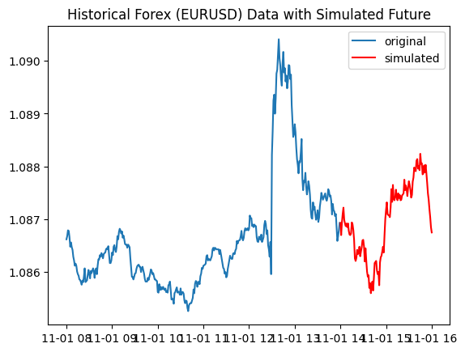

```python
model = ARIMA(TS_lastsixhour, order=(22, 0, 2))
fitted_model = model.fit()
forecast = fitted_model.simulate(nsimulations=horizon)
forecast = np.concatenate(([last_value],forecast))

simulated_time_index = pd.date_range(start=TS_lastsixhour.index[-1] + pd.DateOffset(minutes=1), periods=horizon+1, freq='min')
FCST_df = pd.DataFrame((pd.to_datetime(simulated_time_index),np.round(forecast,5))).T
FCST_df.columns = ["ds","y"]
DF_lastsixhour = pd.DataFrame((TS_lastsixhour.index,TS_lastsixhour)).T
DF_lastsixhour.columns = ["ds","y"]

plt.plot(DF_lastsixhour["ds"],DF_lastsixhour["y"],label="original")
plt.plot(FCST_df["ds"],FCST_df["y"],color="red",label="simulated")
plt.title(f"Historical Forex ({def_pair}) Data with Simulated Future")
plt.legend()
```

This looks good, seems like a perfeclty natural progression with no extreme “market events”. We will use this simulated data to allocated liquidity over.

First, we need to create some variation/noise in the spreads for each liquidity provider.

My first instinct was to use a Normal R.V as noise for each time step, but this was too chaotic, and not really a good replication of real world behaviour.

Instead, i’ve gone with Fractional Brownian Motion; this provides a smoother variation in our noise, and even adds a trend. The trend will create overlaps of LPs’ bids/asks, therefore changing the optimal decisions to be made over liquidity provision. Exactly what we need to test our model for.

Below you can see the process of creating the noise, and then adding it to our simulated preference price (market price), since the spread of any LP always tends to encapsulate this value anyway, otherwise nobody would use them.

```
121
121
```

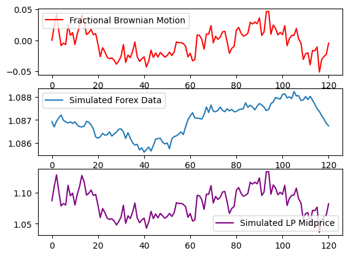

```python
fig, axes = plt.subplots(3,1,)
f = FBM(n=120, hurst=0.3, length=pip_sizes[0])
smooth_random_series = f.fbm()
axes[0].plot(smooth_random_series,label="Fractional Brownian Motion",color="red")
axes[0].legend()

axes[1].plot(FCST_df["y"],label="Simulated Forex Data")
axes[1].legend()

random_mid = FCST_df["y"].values + smooth_random_series
axes[2].plot(random_mid,label="Simulated LP Midprice",color="purple")
axes[2].legend()

print(len(FCST_df["y"]))
print(len(smooth_random_series))
```

## Spreads

Now for each liquidity provider, I track the importants variables such as Bid, Ask, Spread, Residual for each LP at each price point. And implementing a price impact proportional to the value invested. This reflects the real world condition where LPs will increase the spread for larger orders.

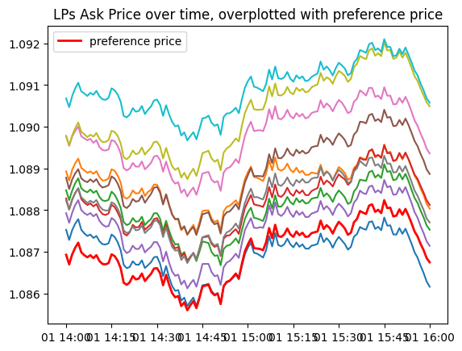

```python
def live_simulute_liquidity_providers(LP_data,simulated_data,pip_sizes,init_cash):
    results = []

    spread_scale = (pip_sizes/100)*init_cash
    max_spread = np.max([LP["Spread"] for LP in LP_data])
    min_spread = np.min([LP["Spread"] for LP in LP_data])
    for i,LP in enumerate(LP_data):
        f = FBM(n=120, hurst=0.8, length=pip_sizes)
        smooth_random_series = f.fbm()
        spreads = []
        lp_evolution = []
        mids = (simulated_data["y"].values + smooth_random_series) + spread_scale
        base_spread = LP["Spread"]
        for t,price_points in enumerate(simulated_data["y"]):
            ask = mids[t] + base_spread/2
            bid = ask - base_spread
            spreads.append(ask-bid)
            base_price = price_points
            lp_evolution.append({"LP":i+1,"Price":base_price,"Spread":ask-bid,"Bid":bid,"Ask":ask,"Mid":mids[t],"Residual":ask-base_price})
        results.append(lp_evolution)
    return results

init_cash = 50
simulated_data = FCST_df
lp_results = live_simulute_liquidity_providers(LP_data,simulated_data,pip_sizes[0],init_cash)

for lp_evolution in lp_results:
    asks = [entry["Ask"] for entry in lp_evolution]
    plt.plot(FCST_df["ds"], asks)
    #bids = [entry["Bid"] for entry in lp_evolution]
    #plt.plot(FCST_df["ds"], bids)
plt.plot(FCST_df["ds"],FCST_df["y"],color="red",lw=2,label="preference price")
plt.title("LPs Ask Price over time, overplotted with preference price")
plt.legend()
```

We can see above the evolution of the Ask prices for each LP at each time-frame. We can see that the residuals are not constant, and that at different times we will see a more optimal choice of LPs.

Now let’s visualise the residual of each LP over time.

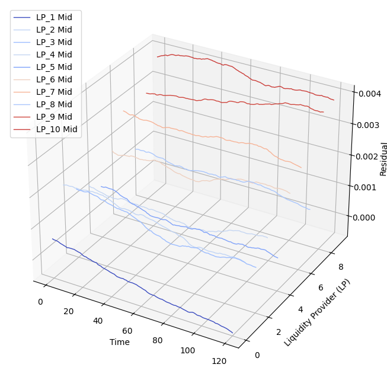

```python
def plot_liquidity_provider_spreads(results):
    fig = plt.figure(figsize=(12, 8))
    ax = fig.add_subplot(111, projection='3d')
    all_res = [entry['Residual'] for lp_data in results for entry in lp_data]
    norm = mcolors.Normalize(vmin=min(all_res), vmax=max(all_res))
    colormap = plt.cm.coolwarm

    for i, lp_data in enumerate(results):
        time_points = range(len(lp_data))
        res_values = [entry['Residual'] for entry in lp_data]
        bid_values = [entry['Bid'] for entry in lp_data]
        ask_values = [entry['Ask'] for entry in lp_data]
        mids = [(bid + ask) / 2 for bid, ask in zip(bid_values, ask_values)]

        colors = colormap(norm(res_values))
        ax.plot(time_points, [i]*len(time_points), res_values,color=colors[-1] ,label=f"LP_{i+1} Mid",lw=1)

        # Optionally, plot Bid and Ask over time as separate lines for each LP
        #ax.plot(time_points, [i]*len(time_points), bid_values,color=colors[-1] ,linestyle="--" )
        #ax.plot(time_points, [i]*len(time_points), ask_values,color=colors[-1] ,linestyle="--")

    ax.set_xlabel('Time')
    ax.set_ylabel('Liquidity Provider (LP)')
    ax.set_zlabel('Residual')
    ax.legend()
    plt.show()

plot_liquidity_provider_spreads(lp_results)
```

## Correlation

Residuals & Spreads are no the only important factor to consider when optimising liquidity allocation.

Correlation is also important. If you select two similarly correlated then you are not diversifying your risk appropriately. This is for risk reduction, so if your selected LPs decide to raise costs simultaneously (which is more likely with highly correlated LPs) then you will end up paying more. Similarly, the price impact may be reduced if you spread liquidity over LPs with different hedging and risk allocation strategies.

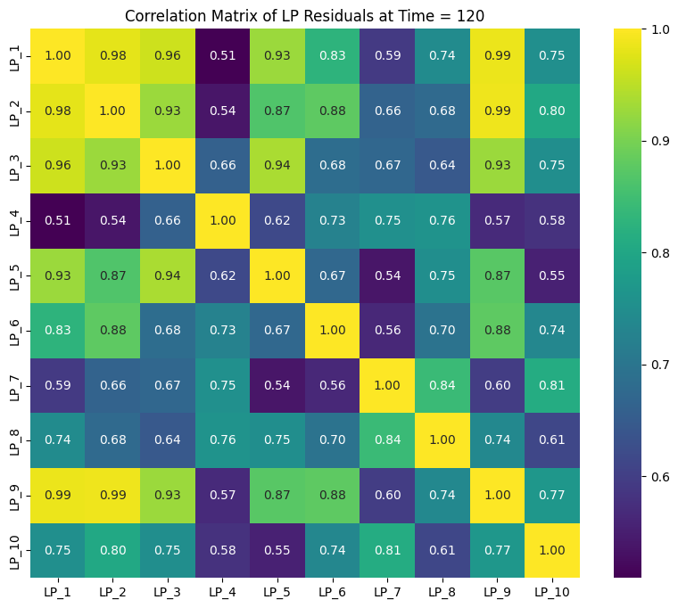

```python
corr_matrices_all = []
for time_step in lp_results:
    residuals = []
    for lp_entry in time_step:
        lp_name = lp_entry["LP"]
        residual = lp_entry['Residual']
        residuals.append({'LP': lp_name, 'Residual': residual})

    df = residuals
    corr_matrices_all.append(df)

residual_columnised = pd.DataFrame(columns=["LP_1", "LP_2", "LP_3", "LP_4", "LP_5", "LP_6", "LP_7", "LP_8", "LP_9", "LP_10"])
index = 0
for LP in corr_matrices_all:
    col_dat = []
    for time_step in LP:
        col_dat.append(time_step["Residual"])
    residual_columnised[f"LP_{index+1}"] = col_dat
    index += 1

cumulative_corr_matrices = []

for i in range(1, len(residual_columnised) + 1):
    if i == 1 or i == 2:
            correlation_matrix = pd.DataFrame(0, index=residual_columnised.columns, columns=residual_columnised.columns)
    else:
        cumulative_data = residual_columnised.iloc[:i]
        correlation_matrix = cumulative_data.corr().abs()
        correlation_matrix = (correlation_matrix + 1) / 2
    cumulative_corr_matrices.append(correlation_matrix)


plt.figure(figsize=(10, 8))
sns.heatmap(cumulative_corr_matrices[-1], annot=True, fmt=".2f", cmap="viridis", square=True)
plt.title(f'Correlation Matrix of LP Residuals at Time = {horizon}')
plt.show()
```

Above is our correlation matrix at time t = T

And below you can see the evolution of this matrix over all time frames.

[figure not shown]

Correlation Over Time

```python
#fig, ax = plt.subplots(figsize=(8, 6))
cax = ax.matshow(np.zeros((10, 10)), cmap="viridis", vmin=-1, vmax=1)
def update(frame):
    corr_matrix = cumulative_corr_matrices[frame]
    ax.clear()
    ax.matshow(corr_matrix, cmap="viridis", vmin=-1, vmax=1)
    ax.set_title(f"Time Step: {frame + 1}")

fig.colorbar(cax)
#anim = FuncAnimation(fig, update, frames=len(cumulative_corr_matrices), interval=500, repeat=False)
#anim.save('correlation_animation.gif', writer='pillow')
```

## Optimal Allocation

Now we have analysed two key factors for our allocation. We need to decide which LPs to select.

Here I have decided to select top-3 LPs under this criteria. However, you can set the parameter to whatever you desire.

```python
def optimal_evolutions(residual_columnised,cumulative_corr_matrices,num_to_select=3):
    optimal_allocations = []
    for i in range(len(residual_columnised)):
        LP_score = []
        for LP in residual_columnised:
            corr_index = int((LP.split("_")[1]))
            res_score = residual_columnised[LP][i]
            corr_scores = (cumulative_corr_matrices[i].mean(axis=0).values)
            corr_scores = corr_scores[corr_index-1]
            res_normed = (res_score-min(residual_columnised[LP]))/(max(residual_columnised[LP])-min(residual_columnised[LP]))
            total_score = (-res_normed*1.25)+(-corr_scores)
            LP_score.append(total_score)
        LP_sorted = np.argsort(LP_score)[:num_to_select]
        optimal_allocations.append(LP_sorted)
    return optimal_allocations

optimal_allocations = optimal_evolutions(residual_columnised,cumulative_corr_matrices,num_to_select=3)
optimal_allocations[:10]
```

```
[array([0, 2, 4], dtype=int64),
 array([0, 7, 2], dtype=int64),
 array([0, 7, 2], dtype=int64),
 array([0, 1, 4], dtype=int64),
 array([0, 4, 1], dtype=int64),
 array([0, 4, 1], dtype=int64),
 array([1, 7, 0], dtype=int64),
 array([1, 4, 0], dtype=int64),
 array([2, 4, 0], dtype=int64),
 array([2, 7, 0], dtype=int64)]
```

## Results

Let’s view a distribution of how often each LP was selected.

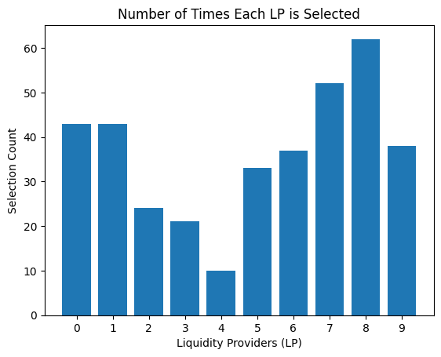

```python
lp_counts = {f"{i}": 0 for i in range(10)}  # Assuming 10 LPs

for allocation in optimal_allocations:
    for lp in allocation:
        lp_counts[f"{lp}"] += 1

plt.bar(lp_counts.keys(), lp_counts.values())
plt.title("Number of Times Each LP is Selected")
plt.xlabel("Liquidity Providers (LP)")
plt.ylabel("Selection Count")
plt.show()
```

And here we can see for each time step the set of LPs selected as most optimal under our metric.

[figure not shown]

Liquidity Correlation GIF

```python
#fig, ax = plt.subplots(figsize=(10, 6))
lp_labels = [f"LP_{i+1}" for i in range(10)]
bars = ax.bar(lp_labels, [0] * 10)
ax.set_ylim(0, 1.1)
ax.set_title('LP Selection Over Time')
ax.set_xlabel('Liquidity Providers')
ax.set_ylabel('Selected (1) / Not Selected (0)')
bars = ax.bar(np.arange(10), np.zeros(10), color='skyblue', edgecolor='darkblue')

def update(frame):
    ax.set_title(f"Time Step: {frame + 1}")
    selection = [1 if i in optimal_allocations[frame] else 0 for i in range(10)]

    for i, bar in enumerate(bars):
        bar.set_height(selection[i])

#anim = FuncAnimation(fig, update, frames=len(optimal_allocations), interval=500, repeat=False)
#anim.save('LiquidityAllocation.gif', writer='pillow')
#plt.show()
```